# Project: Identify Customer Segments

## $\color{red}{\text{Leo's comments}}$

- please note that this is a snapshot from "Data_Dictionary.MD" file on mixed data (and what each number represents)

##### 1.18. PRAEGENDE_JUGENDJAHRE

Dominating movement of person's youth (avantgarde vs. mainstream; east vs. west)

- -1: unknown
- 0: unknown
- 1: 40s - war years (Mainstream, E+W)
- 2: 40s - reconstruction years (Avantgarde, E+W)
- 3: 50s - economic miracle (Mainstream, E+W)
- 4: 50s - milk bar / Individualisation (Avantgarde, E+W)
- 5: 60s - economic miracle (Mainstream, E+W)
- 6: 60s - generation 68 / student protestors (Avantgarde, W)
- 7: 60s - opponents to the building of the Wall (Avantgarde, E)
- 8: 70s - family orientation (Mainstream, E+W)
- 9: 70s - peace movement (Avantgarde, E+W)
- 10: 80s - Generation Golf (Mainstream, W)
- 11: 80s - ecological awareness (Avantgarde, W)
- 12: 80s - FDJ / communist party youth organisation (Mainstream, E)
- 13: 80s - Swords into ploughshares (Avantgarde, E)
- 14: 90s - digital media kids (Mainstream, E+W)
- 15: 90s - ecological awareness (Avantgarde, E+W)

##### 4.3. CAMEO_INTL_2015

German CAMEO: Wealth / Life Stage Typology, mapped to international code

- -1: unknown
- 11: Wealthy Households - Pre-Family Couples & Singles
- 12: Wealthy Households - Young Couples With Children
- 13: Wealthy Households - Families With School Age Children
- 14: Wealthy Households - Older Families & Mature Couples
- 15: Wealthy Households - Elders In Retirement
- 21: Prosperous Households - Pre-Family Couples & Singles
- 22: Prosperous Households - Young Couples With Children
- 23: Prosperous Households - Families With School Age Children
- 24: Prosperous Households - Older Families & Mature Couples
- 25: Prosperous Households - Elders In Retirement
- 31: Comfortable Households - Pre-Family Couples & Singles
- 32: Comfortable Households - Young Couples With Children
- 33: Comfortable Households - Families With School Age Children
- 34: Comfortable Households - Older Families & Mature Couples
- 35: Comfortable Households - Elders In Retirement
- 41: Less Affluent Households - Pre-Family Couples & Singles
- 42: Less Affluent Households - Young Couples With Children
- 43: Less Affluent Households - Families With School Age Children
- 44: Less Affluent Households - Older Families & Mature Couples
- 45: Less Affluent Households - Elders In Retirement
- 51: Poorer Households - Pre-Family Couples & Singles
- 52: Poorer Households - Young Couples With Children
- 53: Poorer Households - Families With School Age Children
- 54: Poorer Households - Older Families & Mature Couples
- 55: Poorer Households - Elders In Retirement
- XX: unknown

```python
#similar to cat_feat_list_clean, we are now addresssing "mixed" categorical features
mixed_feat_list_clean = feat_info_clean[feat_info_clean['type']=='mixed']['attribute']
mixed_feat_list_clean
```

```
15      LP_LEBENSPHASE_FEIN
16      LP_LEBENSPHASE_GROB
22    PRAEGENDE_JUGENDJAHRE
56                 WOHNLAGE
59          CAMEO_INTL_2015
79              PLZ8_BAUMAX
Name: attribute, dtype: object
```

### $\color{red}{\text{Leo's comments}}$

- Investigate "PRAEGENDE_JUGENDJAHRE"

```python
#spot check a few, particulary the one mentioned in the notebooks
mixed_feat_list_clean[22]
```

```
'PRAEGENDE_JUGENDJAHRE'
```

```python
azdias_good[mixed_feat_list_clean].head()
```

|  | LP_LEBENSPHASE_FEIN | LP_LEBENSPHASE_GROB | PRAEGENDE_JUGENDJAHRE | WOHNLAGE | CAMEO_INTL_2015 | PLZ8_BAUMAX |
| --- | --- | --- | --- | --- | --- | --- |
| 1 | 21.0 | 6.0 | 14.0 | 4.0 | 51 | 1.0 |
| 2 | 3.0 | 1.0 | 15.0 | 2.0 | 24 | 1.0 |
| 3 | NaN | NaN | 8.0 | 7.0 | 12 | 1.0 |
| 4 | 32.0 | 10.0 | 8.0 | 3.0 | 43 | 2.0 |
| 5 | 8.0 | 2.0 | 3.0 | 7.0 | 54 | 1.0 |

```python
feat_info[feat_info['attribute']=='PRAEGENDE_JUGENDJAHRE']
```

|  | attribute | information_level | type | missing_or_unknown |
| --- | --- | --- | --- | --- |
| 22 | PRAEGENDE_JUGENDJAHRE | person | mixed | [-1,0] |

```python
azdias_good['PRAEGENDE_JUGENDJAHRE'].value_counts()
```

```
14.0    182230
8.0     141117
10.0     85506
5.0      84529
3.0      53700
15.0     42277
11.0     35571
9.0      33525
6.0      25632
12.0     24392
1.0      20597
4.0      20433
2.0       7471
13.0      5740
7.0       4004
Name: PRAEGENDE_JUGENDJAHRE, dtype: int64
```

```python
azdias_good['PRAEGENDE_JUGENDJAHRE'].unique()
```

```
array([ 14.,  15.,   8.,   3.,  10.,  11.,   5.,   9.,   6.,   4.,  nan,
         2.,   1.,  12.,  13.,   7.])
```

```python
##create the mainstream variable in binary format
mainstream = [1,3,5,8,10,12,14]
avantgarde = [2,4,6,7,9,11,13,15]
azdias_good['PRAEGENDE_JUGENDJAHRE_MAINSTREAM']=azdias_good['PRAEGENDE_JUGENDJAHRE'].apply(lambda x: 1 if x in mainstream
                                                                                          else 0 if x in avantgarde
                                                                                          else x)
```

```python
azdias_good['PRAEGENDE_JUGENDJAHRE_MAINSTREAM'].unique()
```

```
array([  1.,   0.,  nan])
```

```python
#create decade varialble via "map" function
decade =                                                                        {1: 40.0,
                                                                                2: 40.0,
                                                                                3: 50.0,
                                                                                4: 50.0,
                                                                                5: 60.0,
                                                                                6: 60.0,
                                                                                7: 60.0,
                                                                                8: 70.0,
                                                                                9: 70.0,
                                                                                10: 80.0,
                                                                                11: 80.0,
                                                                                12: 80.0,
                                                                                13: 80.0,
                                                                                14: 90.0,
                                                                                15: 90.0,
                                                                                }

azdias_good['PRAEGENDE_JUGENDJAHRE_DECADE']=azdias_good['PRAEGENDE_JUGENDJAHRE'].map(decade)
azdias_good['PRAEGENDE_JUGENDJAHRE_DECADE'].unique()
```

```
array([ 90.,  70.,  50.,  80.,  60.,  nan,  40.])
```

```python
# drop original column
azdias_good=azdias_good.drop('PRAEGENDE_JUGENDJAHRE',axis=1)
```

### $\color{red}{\text{Leo's comments}}$

- Investigate "CAMEO_INTL_2015" and engineer two new variables.

```python
azdias_good['CAMEO_INTL_2015'].value_counts()
```

```
51    133631
41     92241
24     90981
14     62786
43     56601
54     45344
25     39566
22     33078
23     26557
13     26289
45     26104
55     23915
52     20532
31     18920
34     18491
15     16957
44     14806
12     13214
35     10340
32     10335
33      9916
Name: CAMEO_INTL_2015, dtype: int64
```

```python
##experiment how to split the value into 'tens' places and 'ones' places
test=azdias_good['CAMEO_INTL_2015'].iloc[1]
int(test)
```

```
24
```

```python
#'tens' places
int(test[0])
```

```
2
```

```python
#'ones' places
int(test[1])
```

```
4
```

```python
azdias_good['CAMEO_INTL_2015_WEALTH']=azdias_good['CAMEO_INTL_2015'].apply(lambda x: np.nan if pd.isnull(x)
                                                                                       else int(str(x)[0]))

azdias_good['CAMEO_INTL_2015_STAGE']=azdias_good['CAMEO_INTL_2015'].apply(lambda x: np.nan if pd.isnull(x)
                                                                                       else int(str(x)[1]))
```

```python
##check if the separation looks good
azdias_good[['CAMEO_INTL_2015','CAMEO_INTL_2015_WEALTH','CAMEO_INTL_2015_STAGE']].head()
```

|  | CAMEO_INTL_2015 | CAMEO_INTL_2015_WEALTH | CAMEO_INTL_2015_STAGE |
| --- | --- | --- | --- |
| 1 | 51 | 5.0 | 1.0 |
| 2 | 24 | 2.0 | 4.0 |
| 3 | 12 | 1.0 | 2.0 |
| 4 | 43 | 4.0 | 3.0 |
| 5 | 54 | 5.0 | 4.0 |

```python
# drop original column
azdias_good=azdias_good.drop('CAMEO_INTL_2015',axis=1)
```

#### Discussion 1.2.2: Engineer Mixed-Type Features

### $\color{red}{\text{Leo's comments}}$

- I have found 6 mixed type features, out of which 4 are already ordinal, so there is no change made
- I have transformed the below 2 as per the tips from notebook
  - 'PRAEGENDE_JUGENDJAHRE': by cross-referring to the "data_dictionary.MD", I have mapped it to two variable:
    - "PRAEGENDE_JUGENDJAHRE_MAINSTREAM": binary varialble for movement, where 1 represents "mainstream", 0 represents avantgarde
    - "PRAEGENDE_JUGENDJAHRE_DECADE": interval-type variable for decades where 1 or 2 are mapped to 40s
  - 'CAMEO_INTL_2015': I manage to split the value into 'tens' and 'ones' places and saved them as separate features in
    - 'CAMEO_INTL_2015_WEALTH'
    - 'CAMEO_INTL_2015_STAGE
  - The orginal two variables have been dropped after the creation of new variables

#### Step 1.2.3: Complete Feature Selection

In order to finish this step up, you need to make sure that your data frame now only has the columns that you want to keep. To summarize, the dataframe should consist of the following:

- All numeric, interval, and ordinal type columns from the original dataset.
- Binary categorical features (all numerically-encoded).
- Engineered features from other multi-level categorical features and mixed features.

Make sure that for any new columns that you have engineered, that you've excluded the original columns from the final dataset. Otherwise, their values will interfere with the analysis later on the project. For example, you should not keep "PRAEGENDE_JUGENDJAHRE", since its values won't be useful for the algorithm: only the values derived from it in the engineered features you created should be retained. As a reminder, your data should only be from **the subset with few or no missing values**.

```python
# If there are other re-engineering tasks you need to perform, make sure you
# take care of them here. (Dealing with missing data will come in step 2.1.)
```

```python
# Do whatever you need to in order to ensure that the dataframe only contains
# the columns that should be passed to the algorithm functions.
clean_feature_type = pd.DataFrame(azdias_good.columns)
```

```python
clean_feature_type.columns[0]
```

```
0
```

```python
#rename the column name
clean_feature_type.rename(columns={clean_feature_type.columns[0]:'attribute'}, inplace=True)
```

```python
##LEFT merge with feat_info_copy to check the features with Null type
clean_feature_type_merged = pd.merge(clean_feature_type, feat_info_copy[['attribute','type']], how='left', left_on='attribute', right_on='attribute')
clean_feature_type_merged.head()
```

|  | attribute | type |
| --- | --- | --- |
| 0 | ALTERSKATEGORIE_GROB | ordinal |
| 1 | ANREDE_KZ | categorical |
| 2 | CJT_GESAMTTYP | categorical |
| 3 | FINANZ_MINIMALIST | ordinal |
| 4 | FINANZ_SPARER | ordinal |

```python
clean_feature_type_merged['type'].value_counts()
```

```
ordinal        46
categorical    18
numeric         6
mixed           4
Name: type, dtype: int64
```

```python
pd.get_option("display.max_rows")
pd.set_option("display.max_rows", 150)
```

```python
##eye ball all the newly created features (all should be with NaN for feature type during the mapping)

clean_feature_type_merged[clean_feature_type_merged['type'].isnull()]
```

|  | attribute | type |
| --- | --- | --- |
| 74 | PRAEGENDE_JUGENDJAHRE_MAINSTREAM | NaN |
| 75 | PRAEGENDE_JUGENDJAHRE_DECADE | NaN |
| 76 | CAMEO_INTL_2015_WEALTH | NaN |
| 77 | CAMEO_INTL_2015_STAGE | NaN |

### $\color{red}{\text{Leo's comments}}$

- as per the table above, the feature with null type are all self-created ones, which is good
- since the check is done, I will work on the multi-level categorical data and convert them into dummy variables (see below)

```python
#before create dummy variables, please make sure the dtypes are consistent(e.g all in float 2.0, or all in int 2)
##find the columns that are still with str format
str_ls=[]
for y in azdias_good.columns:
    if (is_string_dtype(azdias_good[y])):
        str_ls.append(y)
##only touch the other columns without str format, and convet to float
azdias_good[azdias_good.columns[~azdias_good.columns.isin(str_ls)]]=azdias_good[azdias_good.columns[~azdias_good.columns.isin(str_ls)]].astype(float)
```

```python
## remember to convert the multi-level categorical data into dummy variables
azdias_good_wt_dummy = pd.get_dummies(azdias_good, columns=multi_lv_cat)
```

```python
print(azdias_good.shape, '\n')
print(azdias_good_wt_dummy.shape, '\n')
```

```
(794935, 78)

(794935, 193)
```

### $\color{red}{\text{Leo's comments}}$

- The above steps ( 0 - 1.2 ) have been "packaged" up in step 1.3: "clean_data" function.
- For future interations, please start from step 1.3

### Step 1.3: Create a Cleaning Function

Even though you've finished cleaning up the general population demographics data, it's important to look ahead to the future and realize that you'll need to perform the same cleaning steps on the customer demographics data. In this substep, complete the function below to execute the main feature selection, encoding, and re-engineering steps you performed above. Then, when it comes to looking at the customer data in Step 3, you can just run this function on that DataFrame to get the trimmed dataset in a single step.

```python
# import libraries here; add more as necessary
import numpy as np
import pandas as pd
import matplotlib.pyplot as plt
import seaborn as sns

# magic word for producing visualizations in notebook
%matplotlib inline

from pandas.api.types import is_string_dtype
from pandas.api.types import is_numeric_dtype
```

```python
def clean_data(df):
    """
    Perform feature trimming, re-encoding, and engineering for demographics
    data

    INPUT: Demographics DataFrame
    OUTPUT: Trimmed and cleaned demographics DataFrame
    """

    # Put in code here to execute all main cleaning steps:

    # import libraries here; add more as necessary
    import numpy as np
    import pandas as pd
    import matplotlib.pyplot as plt
    import seaborn as sns

    # magic word for producing visualizations in notebook
    %matplotlib inline

    # convert missing value codes into NaNs, ...
    feat_info=pd.read_csv('AZDIAS_Feature_Summary.csv', sep=';')
    feat_info_copy=feat_info.copy()
    feat_info_copy['missing_or_unknown']=feat_info_copy['missing_or_unknown'].str.strip('[').str.strip(']').str.split(',')

    def is_int(value):
      try:
        int(value)
        return True
      except ValueError:
        return False


    for c, i in enumerate(feat_info_copy['missing_or_unknown']):
        ls=[]
        for j in i:
            if is_int(j):
                ls.append(int(j))
            else:
                ls.append(j)
        feat_info_copy['missing_or_unknown'].loc[c]=ls

    missing_value = feat_info_copy.set_index('attribute')['missing_or_unknown']


    # convert from missing or unkown value (e.g. 0, 1, X) to np.nan
    for col in df.columns:
        df[col] = df[col].replace(missing_value.loc[col], np.nan)


    # select, re-encode, and engineer column values.

    # remove selected columns
    outlier_col=['TITEL_KZ','AGER_TYP', 'KK_KUNDENTYP', 'KBA05_BAUMAX', 'GEBURTSJAHR', 'ALTER_HH', 'REGIOTYP', 'KKK', 'W_KEIT_KIND_HH']
    df_clean=df.drop(columns=outlier_col)



    # remove selected rows (>20% missing feature)
    missing_feature_per_sample=(df_clean.isnull().sum(axis=1)/df_clean.shape[1]*100)
    df_clean= df_clean.join(pd.DataFrame(missing_feature_per_sample))
    df_clean.rename(columns={df_clean.columns[-1]:'%MissingFeature'}, inplace = True)
    df_clean=df_clean[df_clean['%MissingFeature']<=20]
    df_clean=df_clean.drop(columns=['%MissingFeature'])



    # select, re-encode, and engineer column values.

    ##categorical features
    feat_info_clean = feat_info_copy[~feat_info_copy['attribute'].isin(outlier_col)]

    cat_feat_list_clean = feat_info_clean[feat_info_clean['type']=='categorical']['attribute']
    binary_cat=[]
    multi_lv_cat=[]
    for i in cat_feat_list_clean:
        if len(df_clean[i].dropna().unique())==2:
            binary_cat.append(i)
        elif len(df_clean[i].dropna().unique())>2:
            multi_lv_cat.append(i)

    ###categorical features: binary
    df_clean['OST_WEST_KZ'].replace(['W','O'],[1.0,0.0], inplace = True)
    df_clean['ANREDE_KZ'].replace([2,1],[1.0,0.0], inplace = True)
    df_clean['VERS_TYP'].replace([2.0,1.0],[1.0,0.0], inplace = True)

    ##categorical features: multi level (leave it to the last step)
#     df_clean = pd.get_dummies(df_clean, columns=multi_lv_cat)



    ##mixed feature
    mainstream = [1,3,5,8,10,12,14]
    avantgarde = [2,4,6,7,9,11,13,15]
    df_clean['PRAEGENDE_JUGENDJAHRE_MAINSTREAM']=df_clean['PRAEGENDE_JUGENDJAHRE'].apply(lambda x: 1 if x in mainstream
                                                                                          else 0 if x in avantgarde
                                                                                          else x)
    decade= {1: 40.0,
             2: 40.0,
             3: 50.0,
             4: 50.0,
             5: 60.0,
             6: 60.0,
             7: 60.0,
             8: 70.0,
             9: 70.0,
             10: 80.0,
             11: 80.0,
             12: 80.0,
             13: 80.0,
             14: 90.0,
             15: 90.0}

    df_clean['PRAEGENDE_JUGENDJAHRE_DECADE']=df_clean['PRAEGENDE_JUGENDJAHRE'].map(decade)
    df_clean=df_clean.drop('PRAEGENDE_JUGENDJAHRE',axis=1)

    df_clean['CAMEO_INTL_2015_WEALTH']=df_clean['CAMEO_INTL_2015'].apply(lambda x: np.nan if pd.isnull(x)
                                                                                       else int(str(x)[0]))

    df_clean['CAMEO_INTL_2015_STAGE']=df_clean['CAMEO_INTL_2015'].apply(lambda x: np.nan if pd.isnull(x)
                                                                                       else int(str(x)[1]))
    df_clean=df_clean.drop('CAMEO_INTL_2015',axis=1)

    #before create dummy variables, please make sure the dtypes are consistent(e.g all in float 2.0, or all in int 2)
    #otherwise the dummy variable would be different: xx_5 vs xx_5.0

#     ##find the columns that are still with str format
#     str_ls=[]
#     for y in df_clean.columns:
#         if (is_string_dtype(df_clean[y])):
#             str_ls.append(y)
#     ##only touch the other columns without str format, and convet to float
#     df_clean[df_clean.columns[~df_clean.columns.isin(str_ls)]]=df_clean[df_clean.columns[~df_clean.columns.isin(str_ls)]].astype(float)

    df_clean_wt_dummy = pd.get_dummies(df_clean, columns=multi_lv_cat)

    # Return the cleaned dataframe.
    return df_clean,df_clean_wt_dummy
```

```python
##check the shape of customer data
##I expect the df with dummy would have different column from azdias, because some varilable might be truncated before dummy conversion

customers=pd.read_csv('Udacity_CUSTOMERS_Subset.csv', sep=';')
customers_good,customers_good_wt_dummy=clean_data(customers)

print(customers_good.shape,'/n')
print(customers_good_wt_dummy.shape,'/n')
```

```
(141232, 78) /n
(141232, 192) /n
```

```python
#check the shape of the azdias data, with using the new function
#it should match the above output
azdias_func=pd.read_csv('Udacity_AZDIAS_Subset.csv', sep=';')
azdias_good_func,azdias_good_wt_dummy_func=clean_data(azdias_func)
print(azdias_good_func.shape,'\n')
print(azdias_good_wt_dummy_func.shape,'\n')
```

```
(794935, 78)

(794935, 193)
```

```python
# #check the shape of the azdias data, without using the new function
print(azdias_good.shape, '\n')
print(azdias_good_wt_dummy.shape, '\n')
```

```
(794935, 78)

(794935, 193)
```

```python
# ##reconcile the manual run against the function run
# ##there should be no difference in between
a=azdias_good.columns.tolist()
b=azdias_good_func.columns.tolist()
x=set(a).difference(set(b))
y=set(b).difference(set(a))
print(x,y)
```

```
set() set()
```

## $\color{red}{\text{Leo's comments}}$

- As a sanity check shown above, I compare the azdias data, between
  - the initial manual load (without using clea_data function): azdias_good + azdias_good_wt_dummy
  - the latest load via clean_data function: azdias_good_func + azdias_good_wt_dummy_func
- As another sanity check, I compare the list of columns (before dummy conversion). all mached up.
- As shown by the results above, both sanity checks is satisfactory, proving that **the clean_data functions works as intended**

```python
# #just to check all values (except str) have been converted from int to float
# #otherwise the dummy variable would have xx_5 vs xx_5.0

print(azdias['ALTERSKATEGORIE_GROB'].unique(),'\n')
print(azdias_good['ALTERSKATEGORIE_GROB'].unique(),'\n')

print(customers['ALTERSKATEGORIE_GROB'].unique(),'\n')
print(customers_good['ALTERSKATEGORIE_GROB'].unique(),'\n')
```

```
[2 1 3 4 9]

[  1.   3.   4.   2.  nan]

[  4.   3.   2.   1.  nan]

[  4.   3.   2.   1.  nan]
```

## Step 2: Feature Transformation

### Step 2.1: Apply Feature Scaling

Before we apply dimensionality reduction techniques to the data, we need to perform feature scaling so that the principal component vectors are not influenced by the natural differences in scale for features. Starting from this part of the project, you'll want to keep an eye on the [API reference page for sklearn](http://scikit-learn.org/stable/modules/classes.html) to help you navigate to all of the classes and functions that you'll need. In this substep, you'll need to check the following:

- sklearn requires that data not have missing values in order for its estimators to work properly. So, before applying the scaler to your data, make sure that you've cleaned the DataFrame of the remaining missing values. This can be as simple as just removing all data points with missing data, or applying an [Imputer](http://scikit-learn.org/stable/modules/generated/sklearn.preprocessing.Imputer.html) to replace all missing values. You might also try a more complicated procedure where you temporarily remove missing values in order to compute the scaling parameters before re-introducing those missing values and applying imputation. Think about how much missing data you have and what possible effects each approach might have on your analysis, and justify your decision in the discussion section below.
- For the actual scaling function, a [StandardScaler](http://scikit-learn.org/stable/modules/generated/sklearn.preprocessing.StandardScaler.html) instance is suggested, scaling each feature to mean 0 and standard deviation 1.
- For these classes, you can make use of the `.fit_transform()` method to both fit a procedure to the data as well as apply the transformation to the data at the same time. Don't forget to keep the fit sklearn objects handy, since you'll be applying them to the customer demographics data towards the end of the project.

```python
# If you've not yet cleaned the dataset of all NaN values, then investigate and
# do that now.

##total number of nans
num_nans=azdias_good_wt_dummy_func.isnull().sum().sum()
```

```python
##total size of the values
mum_value=azdias_good_wt_dummy_func.shape[0] * azdias_good_wt_dummy_func.shape[1]
```

```python
print('%nan: {0:.4f}%'.format(num_nans/mum_value*100))
```

```
%nan: 0.4202%
```

```python
#impute nans, toggle between most_frequent and median strategy
from sklearn.preprocessing import Imputer
imputer_frequent=Imputer(strategy='most_frequent')
imputer_median=Imputer(strategy='median')

azdias_imputed=imputer_frequent.fit_transform(azdias_good_wt_dummy_func)
##let's use 'most frequent' strategy
azdias_imputed = pd.DataFrame(azdias_imputed,
                              columns=azdias_good_wt_dummy_func.columns,
                              index=azdias_good_wt_dummy_func.index)
```

```python
azdias_imputed.head()
```

|  | ALTERSKATEGORIE_GROB | ANREDE_KZ | FINANZ_MINIMALIST | FINANZ_SPARER | FINANZ_VORSORGER | FINANZ_ANLEGER | FINANZ_UNAUFFAELLIGER | FINANZ_HAUSBAUER | GREEN_AVANTGARDE | HEALTH_TYP | ... | CAMEO_DEU_2015_7E | CAMEO_DEU_2015_8A | CAMEO_DEU_2015_8B | CAMEO_DEU_2015_8C | CAMEO_DEU_2015_8D | CAMEO_DEU_2015_9A | CAMEO_DEU_2015_9B | CAMEO_DEU_2015_9C | CAMEO_DEU_2015_9D | CAMEO_DEU_2015_9E |
| --- | --- | --- | --- | --- | --- | --- | --- | --- | --- | --- | --- | --- | --- | --- | --- | --- | --- | --- | --- | --- | --- |
| 1 | 1.0 | 1.0 | 1.0 | 5.0 | 2.0 | 5.0 | 4.0 | 5.0 | 0.0 | 3.0 | ... | 0.0 | 1.0 | 0.0 | 0.0 | 0.0 | 0.0 | 0.0 | 0.0 | 0.0 | 0.0 |
| 2 | 3.0 | 1.0 | 1.0 | 4.0 | 1.0 | 2.0 | 3.0 | 5.0 | 1.0 | 3.0 | ... | 0.0 | 0.0 | 0.0 | 0.0 | 0.0 | 0.0 | 0.0 | 0.0 | 0.0 | 0.0 |
| 3 | 4.0 | 1.0 | 4.0 | 2.0 | 5.0 | 2.0 | 1.0 | 2.0 | 0.0 | 2.0 | ... | 0.0 | 0.0 | 0.0 | 0.0 | 0.0 | 0.0 | 0.0 | 0.0 | 0.0 | 0.0 |
| 4 | 3.0 | 0.0 | 4.0 | 3.0 | 4.0 | 1.0 | 3.0 | 2.0 | 0.0 | 3.0 | ... | 0.0 | 0.0 | 0.0 | 0.0 | 0.0 | 0.0 | 0.0 | 0.0 | 0.0 | 0.0 |
| 5 | 1.0 | 1.0 | 3.0 | 1.0 | 5.0 | 2.0 | 2.0 | 5.0 | 0.0 | 3.0 | ... | 0.0 | 0.0 | 0.0 | 1.0 | 0.0 | 0.0 | 0.0 | 0.0 | 0.0 | 0.0 |

5 rows × 193 columns

```python
# Apply feature scaling to the general population demographics data.
from sklearn.preprocessing import StandardScaler
scaler=StandardScaler()
azdias_imputed_standardized=scaler.fit_transform(azdias_imputed)
azdias_imputed_standardized=pd.DataFrame(azdias_imputed_standardized,
                                         columns=azdias_imputed.columns,
                                         index=azdias_imputed.index)
```

```python
azdias_imputed_standardized.head()
```

|  | ALTERSKATEGORIE_GROB | ANREDE_KZ | FINANZ_MINIMALIST | FINANZ_SPARER | FINANZ_VORSORGER | FINANZ_ANLEGER | FINANZ_UNAUFFAELLIGER | FINANZ_HAUSBAUER | GREEN_AVANTGARDE | HEALTH_TYP | ... | CAMEO_DEU_2015_7E | CAMEO_DEU_2015_8A | CAMEO_DEU_2015_8B | CAMEO_DEU_2015_8C | CAMEO_DEU_2015_8D | CAMEO_DEU_2015_9A | CAMEO_DEU_2015_9B | CAMEO_DEU_2015_9C | CAMEO_DEU_2015_9D | CAMEO_DEU_2015_9E |
| --- | --- | --- | --- | --- | --- | --- | --- | --- | --- | --- | --- | --- | --- | --- | --- | --- | --- | --- | --- | --- | --- |
| 1 | -1.766677 | 0.958090 | -1.493599 | 1.538237 | -1.041347 | 1.466279 | 0.962673 | 1.336787 | -0.530632 | 1.009785 | ... | -0.076491 | 3.764105 | -0.209422 | -0.201338 | -0.1503 | -0.162829 | -0.189857 | -0.180132 | -0.193129 | -0.089764 |
| 2 | 0.200222 | 0.958090 | -1.493599 | 0.864967 | -1.767639 | -0.570805 | 0.247577 | 1.336787 | 1.884545 | 1.009785 | ... | -0.076491 | -0.265667 | -0.209422 | -0.201338 | -0.1503 | -0.162829 | -0.189857 | -0.180132 | -0.193129 | -0.089764 |
| 3 | 1.183671 | 0.958090 | 0.684036 | -0.481573 | 1.137526 | -0.570805 | -1.182614 | -0.795981 | -0.530632 | -0.312361 | ... | -0.076491 | -0.265667 | -0.209422 | -0.201338 | -0.1503 | -0.162829 | -0.189857 | -0.180132 | -0.193129 | -0.089764 |
| 4 | 0.200222 | -1.043743 | 0.684036 | 0.191697 | 0.411235 | -1.249833 | 0.247577 | -0.795981 | -0.530632 | 1.009785 | ... | -0.076491 | -0.265667 | -0.209422 | -0.201338 | -0.1503 | -0.162829 | -0.189857 | -0.180132 | -0.193129 | -0.089764 |
| 5 | -1.766677 | 0.958090 | -0.041842 | -1.154843 | 1.137526 | -0.570805 | -0.467518 | 1.336787 | -0.530632 | 1.009785 | ... | -0.076491 | -0.265667 | -0.209422 | 4.966763 | -0.1503 | -0.162829 | -0.189857 | -0.180132 | -0.193129 | -0.089764 |

5 rows × 193 columns

### Step 2.2: Perform Dimensionality Reduction

On your scaled data, you are now ready to apply dimensionality reduction techniques.

- Use sklearn's [PCA](http://scikit-learn.org/stable/modules/generated/sklearn.decomposition.PCA.html) class to apply principal component analysis on the data, thus finding the vectors of maximal variance in the data. To start, you should not set any parameters (so all components are computed) or set a number of components that is at least half the number of features (so there's enough features to see the general trend in variability).
- Check out the ratio of variance explained by each principal component as well as the cumulative variance explained. Try plotting the cumulative or sequential values using matplotlib's [`plot()`](https://matplotlib.org/api/_as_gen/matplotlib.pyplot.plot.html) function. Based on what you find, select a value for the number of transformed features you'll retain for the clustering part of the project.
- Once you've made a choice for the number of components to keep, make sure you re-fit a PCA instance to perform the decided-on transformation.

```python
##check all NaNs should be replaced by imputer
azdias_imputed_standardized.isnull().sum().sum()
```

```
0
```

```python
# Apply PCA to the data.
from sklearn.decomposition import PCA

#set the number of component to be half of features, making sure it is integer
n_component = int(0.5 * azdias_imputed_standardized.shape[1])
print(n_component)
```

```
96
```

```python
pca_96=PCA(n_component)
x_pca_96=pca_96.fit_transform(azdias_imputed_standardized)
```

```python
#this is the result in the format of x_pca_96,
print('This is what the orignal data set with shape of ' + str(azdias_imputed_standardized.shape)
      + '\n'
      + 'It looks like after the dimensional reduction via pca fit_transform function. Now it is with a shape of '
        +str(np.shape(x_pca_96))
      + '\n'
     )
```

```
This is what the orignal data set with shape of (794935, 193)
It looks like after the dimensional reduction via pca fit_transform function. Now it is with a shape of (794935, 96)
```

```python
print('this is to check the weights between 96 principal components vs 193 features with a shape of' + str(np.shape(pca_96.components_)), '\n')

print('this is to show the importance of each prinpical components in explaining the variance with a shape of ' +str(np.shape(pca_96.explained_variance_ratio_)))
```

```
this is to check the weights between 96 principal components vs 193 features with a shape of(96, 193)

this is to show the importance of each prinpical components in explaining the variance with a shape of (96,)
```

```python
#quick check the associated attributes available for pca_96, which is the model itself see below
pca_96?
```

```python
#check the first 10 component
pca_96.explained_variance_ratio_[:10]
```

```
array([ 0.08291099,  0.05683738,  0.03546829,  0.02949289,  0.02272505,
        0.01598779,  0.01509201,  0.0134053 ,  0.01298191,  0.01261967])
```

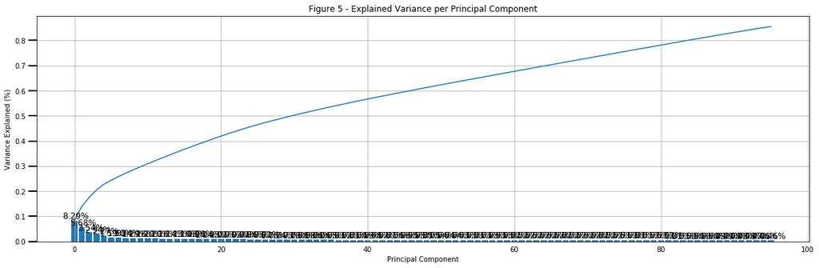

```python
# Investigate the variance accounted for by each principal component.
num_components = len(pca_96.explained_variance_ratio_)

ind=np.arange(num_components)
vals=pca_96.explained_variance_ratio_

plt.figure(figsize = (20,6))
ax = plt.subplot(111)
cumvals=np.cumsum(vals)
ax.bar(ind,vals)
ax.plot(ind,cumvals)

for i in range(num_components):
    ax.annotate(r"%s%%" % ((str(vals[i]*100)[:4])),(ind[i]+0.2, vals[i]), va='bottom', ha='center', fontsize=12)

ax.xaxis.set_tick_params(width=0)
ax.yaxis.set_tick_params(width=2, length=12)

ax.set_xlabel("Principal Component")
ax.set_ylabel("Variance Explained (%)")

plt.title('Figure 5 - Explained Variance per Principal Component')
plt.grid()
```

```python
# Re-apply PCA to the data while selecting for number of components to retain.
#n_component = 96 is still to much. Judging by the above plot, I wil choose 40 comonent, all of which combined can explain about 50% of the variance
from sklearn.decomposition import PCA
pca_40=PCA(40)
x_pca_40=pca_40.fit_transform(azdias_imputed_standardized)
```

### Discussion 2.2: Perform Dimensionality Reduction

### $\color{red}{\text{Leo's comments}}$

- I start with half of the featurs (n_component = 0.5 * 193) as the components for the PCA
- Juding by the chart, I would like to **drop the number of components to 40**, all of which will account for a cumulative variance of 55% of the data

### Step 2.3: Interpret Principal Components

Now that we have our transformed principal components, it's a nice idea to check out the weight of each variable on the first few components to see if they can be interpreted in some fashion.

As a reminder, each principal component is a unit vector that points in the direction of highest variance (after accounting for the variance captured by earlier principal components). The further a weight is from zero, the more the principal component is in the direction of the corresponding feature. If two features have large weights of the same sign (both positive or both negative), then increases in one tend expect to be associated with increases in the other. To contrast, features with different signs can be expected to show a negative correlation: increases in one variable should result in a decrease in the other.

- To investigate the features, you should map each weight to their corresponding feature name, then sort the features according to weight. The most interesting features for each principal component, then, will be those at the beginning and end of the sorted list. Use the data dictionary document to help you understand these most prominent features, their relationships, and what a positive or negative value on the principal component might indicate.
- You should investigate and interpret feature associations from the first three principal components in this substep. To help facilitate this, you should write a function that you can call at any time to print the sorted list of feature weights, for the *i*-th principal component. This might come in handy in the next step of the project, when you interpret the tendencies of the discovered clusters.

```python
pca_40.components_
```

```
array([[-0.07674107,  0.01459644, -0.18416091, ...,  0.05700177,
         0.05528687,  0.01707613],
       [ 0.23730811,  0.04182648,  0.09496983, ...,  0.00507782,
         0.01002992,  0.03789351],
       [ 0.0182557 , -0.33726182,  0.13243846, ...,  0.026317  ,
         0.01299229, -0.00196643],
       ...,
       [-0.05075768,  0.01684971,  0.00338097, ..., -0.08843107,
         0.04432834, -0.01065189],
       [ 0.03255829, -0.01062814,  0.01974921, ..., -0.01575516,
        -0.02872894, -0.12524922],
       [ 0.03687675, -0.01516557,  0.00461008, ...,  0.05426945,
         0.15855195, -0.13548848]])
```

```python
#check the number of components each represents one row,
#40 rows represent 40 pricipal components
#193 columns represent 193 features (including dummies)
np.shape(pca_40.components_)
```

```
(40, 193)
```

```python
# Map weights for the first principal component to corresponding feature names
# and then print the linked values, sorted by weight.
# HINT: Try defining a function here or in a new cell that you can reuse in the
# other cells.
def pca_weights(pca,i):
    '''
    for a trained pca model, find the weights of 193 features that goes into the 40
    INPUT: the trained PCA model, i = i th PCA
    '''
    df = pd.DataFrame(pca.components_, columns=list(azdias_imputed_standardized))
    weights = pd.DataFrame(df.iloc[i].sort_values(ascending=False))
    df_show=weights.head(5).append(weights.tail(5))
    return print(df_show), df_show.plot.bar()
```

```
                               0
LP_STATUS_GROB_1.0      0.189839
HH_EINKOMMEN_SCORE      0.179461
PLZ8_ANTG3              0.178751
CAMEO_INTL_2015_WEALTH  0.178240
PLZ8_ANTG4              0.173341
KBA05_ANTG1            -0.175515
KBA05_GBZ              -0.176157
PLZ8_ANTG1             -0.179848
MOBI_REGIO             -0.183388
FINANZ_MINIMALIST      -0.184161
                                     1
ALTERSKATEGORIE_GROB          0.237308
FINANZ_VORSORGER              0.221830
ZABEOTYP_3                    0.200639
SEMIO_ERL                     0.184875
SEMIO_LUST                    0.164490
SEMIO_TRADV                  -0.210862
FINANZ_UNAUFFAELLIGER        -0.218034
SEMIO_REL                    -0.220810
FINANZ_SPARER                -0.232109
PRAEGENDE_JUGENDJAHRE_DECADE -0.233342
                    2
SEMIO_VERT   0.314046
SEMIO_SOZ    0.253083
SEMIO_FAM    0.251691
SEMIO_KULT   0.244595
FINANZTYP_5  0.137461
SEMIO_ERL   -0.200583
SEMIO_KRIT  -0.264333
SEMIO_DOM   -0.273039
SEMIO_KAEM  -0.303290
ANREDE_KZ   -0.337262
```

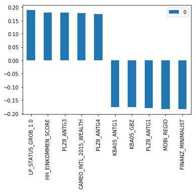

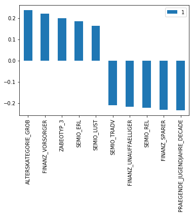

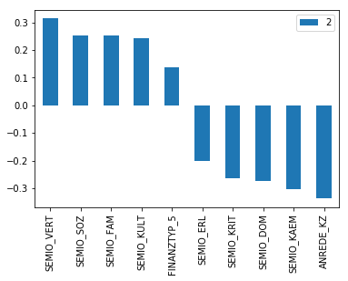

```python
# for each of the top 3 principal components, show
##the top 5 'the most positive associated' features
##and 'top 5 most negatively associated' features
for i in range(0,3):
    pca_weights(pca_40,i)
```

### $\color{red}{\text{Leo's comments}}$

- levearge the same logic for the above funciton, I would like to the find out the **top x feature for each PCA**
- this is for the last part of the project, where I need to make comments about which features are associated with certain clusters (which are over/under-presenting customers data against the asdias data)

```python
pca_components_df = pd.DataFrame(pca_40.components_, columns=list(azdias_imputed_standardized))
```

```python
top_feature_ls=[]
for i in range(0,len(pca_components_df)):
    weights = pd.DataFrame(pca_components_df.iloc[i].sort_values(ascending=False))
    top_feature_ls.append(weights.head(1).index.tolist())
```

```python
top_feature_ls_flatten = [item for sublist in top_feature_ls for item in sublist]
```

```python
#remove the duplicates
top_feature_ls_flatten=list(set(top_feature_ls_flatten))
top_feature_ls_flatten
```

```
['CJT_GESAMTTYP_6.0',
 'LP_FAMILIE_GROB_3.0',
 'LP_STATUS_GROB_3.0',
 'LP_FAMILIE_FEIN_11.0',
 'CAMEO_INTL_2015_STAGE',
 'CJT_GESAMTTYP_5.0',
 'LP_LEBENSPHASE_GROB',
 'GFK_URLAUBERTYP_11.0',
 'GEBAEUDETYP_8.0',
 'CJT_GESAMTTYP_3.0',
 'LP_STATUS_GROB_1.0',
 'CAMEO_DEUG_2015_5',
 'CAMEO_DEUG_2015_4',
 'CAMEO_DEUG_2015_6',
 'NATIONALITAET_KZ_2.0',
 'LP_STATUS_FEIN_7.0',
 'LP_FAMILIE_GROB_2.0',
 'CAMEO_DEUG_2015_8',
 'CAMEO_DEU_2015_9E',
 'LP_STATUS_GROB_4.0',
 'CAMEO_DEUG_2015_9',
 'ALTERSKATEGORIE_GROB',
 'CAMEO_DEUG_2015_3',
 'NATIONALITAET_KZ_1.0',
 'ANZ_TITEL',
 'LP_FAMILIE_GROB_4.0',
 'GEBAEUDETYP_1.0',
 'SHOPPER_TYP_1.0',
 'SEMIO_VERT',
 'PLZ8_HHZ']
```

## Step 3: Clustering

### Step 3.1: Apply Clustering to General Population

You've assessed and cleaned the demographics data, then scaled and transformed them. Now, it's time to see how the data clusters in the principal components space. In this substep, you will apply k-means clustering to the dataset and use the average within-cluster distances from each point to their assigned cluster's centroid to decide on a number of clusters to keep.

- Use sklearn's KMeans class to perform k-means clustering on the PCA-transformed data.
- Then, compute the average difference from each point to its assigned cluster's center. **Hint**: The KMeans object's `.score()` method might be useful here, but note that in sklearn, scores tend to be defined so that larger is better. Try applying it to a small, toy dataset, or use an internet search to help your understanding.
- Perform the above two steps for a number of different cluster counts. You can then see how the average distance decreases with an increasing number of clusters. However, each additional cluster provides a smaller net benefit. Use this fact to select a final number of clusters in which to group the data. **Warning**: because of the large size of the dataset, it can take a long time for the algorithm to resolve. The more clusters to fit, the longer the algorithm will take. You should test for cluster counts through at least 10 clusters to get the full picture, but you shouldn't need to test for a number of clusters above about 30.
- Once you've selected a final number of clusters to use, re-fit a KMeans instance to perform the clustering operation. Make sure that you also obtain the cluster assignments for the general demographics data, since you'll be using them in the final Step 3.3.

```python
# Over a number of different cluster counts...
from sklearn.cluster import KMeans
def kmeans_score(data, n_cluster):

    # run k-means clustering on the data and...
    kmeans=KMeans(n_cluster)
    model=kmeans.fit(data)

    # compute the average within-cluster distances.
    score=np.abs(model.score(data))
    return score
```

```
 Total time to run the full programme(in second):  1590.8122237630014
```

[figure not shown]

```python
import timeit
start_time = timeit.default_timer()

# Investigate the change in within-cluster distance across number of clusters.
# HINT: Use matplotlib's plot function to visualize this relationship.
scores=[]
ls=list(range(1,20,2))
for i in ls:
    scores.append(kmeans_score(x_pca_40,i))
plt.plot(ls, scores, marker='o')
plt.xlabel('n_cluster');
plt.ylabel('kmeans score');
plt.title('Figure 7 - kmeans: score vs. n_clusters');

stop_time = timeit.default_timer()
print('\n Total time to run the full programme(in second): ', stop_time - start_time )
```

### $\color{red}{\text{Leo's comments}}$

```python
# Re-fit the k-means model with the selected number of clusters and obtain
# cluster predictions for the general population demographics data.
from sklearn.cluster import KMeans
kmeans=KMeans(6)
model=kmeans.fit(x_pca_40)
azdias_clustered=model.predict(x_pca_40)
```

### Step 3.2: Apply All Steps to the Customer Data

Now that you have clusters and cluster centers for the general population, it's time to see how the customer data maps on to those clusters. Take care to not confuse this for re-fitting all of the models to the customer data. Instead, you're going to use the fits from the general population to clean, transform, and cluster the customer data. In the last step of the project, you will interpret how the general population fits apply to the customer data.

- Don't forget when loading in the customers data, that it is semicolon (`;`) delimited.
- Apply the same feature wrangling, selection, and engineering steps to the customer demographics using the `clean_data()` function you created earlier. (You can assume that the customer demographics data has similar meaning behind missing data patterns as the general demographics data.)
- Use the sklearn objects from the general demographics data, and apply their transformations to the customers data. That is, you should not be using a `.fit()` or `.fit_transform()` method to re-fit the old objects, nor should you be creating new sklearn objects! Carry the data through the feature scaling, PCA, and clustering steps, obtaining cluster assignments for all of the data in the customer demographics data.

```python
#it looks like the azdias data has one more column than customer data
list(set(azdias_good_wt_dummy_func.columns) - set(customers_good_wt_dummy.columns))
```

```
['GEBAEUDETYP_5.0']
```

```python
#it is okay with the other way around
list(set(customers_good_wt_dummy.columns)- set(azdias_good_wt_dummy_func.columns))
```

```
[]
```

```python
# find the above feature's position in a list
for i,x in enumerate(azdias_good_wt_dummy_func.columns.tolist()):
    if x =='GEBAEUDETYP_5.0':
        print(i)
```

```
137
```

```python
##double chekc to make sure the position is correct
print(azdias_good_wt_dummy_func.columns[[136,137,138]],'\n')
print(customers_good_wt_dummy.columns[[136,137,138]],'\n')
```

```
Index(['GEBAEUDETYP_4.0', 'GEBAEUDETYP_5.0', 'GEBAEUDETYP_6.0'], dtype='object')

Index(['GEBAEUDETYP_4.0', 'GEBAEUDETYP_6.0', 'GEBAEUDETYP_8.0'], dtype='object')
```

```python
#insert an empty column for 'GEBAEUDETYP_5.0'
customers_good_wt_dummy.insert(137,'GEBAEUDETYP_5.0',0)
```

```python
print(customers_good_wt_dummy.columns[[136,137,138]],'\n')
```

```
Index(['GEBAEUDETYP_4.0', 'GEBAEUDETYP_5.0', 'GEBAEUDETYP_6.0'], dtype='object')
```

### $\color{red}{\text{Leo's comments}}$

- as pointed out, we should not use 'fit' or 'fit_transform' to change the data again.
- instead, we should the existing inpmuter, scaler, pca and kmeans **that has already been fitted** for azdias data

```python
# Apply preprocessing, feature transformation, and clustering from the general
# demographics onto the customer data, obtaining cluster predictions for the
# customer demographics data.


#impute - imputer_frequent as previously defined. no fit, transform only.
# imputer_frequent=Imputer(strategy='most_frequent')
print('shape of customers_good_wt_dummy: '+ str(np.shape(customers_good_wt_dummy)), '\n')
customers_imputed = imputer_frequent.transform(customers_good_wt_dummy)
customers_imputed = pd.DataFrame(customers_imputed,
                              columns=customers_good_wt_dummy.columns,
                              index=customers_good_wt_dummy.index)
print('shape of customers_imputed: '+ str(np.shape(customers_imputed)), '\n')

#scaler - transform only, no fit
customers_imputed_standardized=scaler.transform(customers_imputed)
customers_imputed_standardized=pd.DataFrame(customers_imputed_standardized,
                                         columns=customers_imputed.columns,
                                         index=customers_imputed.index)
#pca - transform only. no fit
cumsters_imputed_standardized_pca= pca_40.transform(customers_imputed_standardized)
print('shape of customers_imputed_standardized: '+ str(np.shape(customers_imputed_standardized)), '\n')

#kmeans model, as called previously as 'model'. predict only. not fit
cumsters_imputed_standardized_pca_kmeans=model.predict(cumsters_imputed_standardized_pca)
print('shape of cumsters_imputed_standardized_pca_kmeans: '+ str(np.shape(cumsters_imputed_standardized_pca_kmeans)), '\n')
```

```
shape of customers_good_wt_dummy: (141232, 193)

shape of customers_imputed: (141232, 193)

shape of customers_imputed_standardized: (141232, 193)

shape of cumsters_imputed_standardized_pca_kmeans: (141232,)
```